# **QDNAseq**

Michael Bell, 15002484

05/01/2022

# **Quantitative DNA Sequencing for Chromosomal Aberrations**

## **1: Introduction:**

Scheinin et al. (2014) developed the QDNAseq pipeline to help improve the detection of DNA copy number aberrations from whole-genome sequencing (WGS). The focus of the study was to improve analysis and quantification of the challenges that are presented by WGS; this includes reference genome errors, sequence completions, repeat sequences, polymorphisms, variability in sample quality and procedure bias.

## **1.1: Chromosomal Aberrations:**

Chromosomal aberrations are defined as a change within either the structure or number of a chromosome. Most typical chromosomal aberrations are considered to be aneuploids; meaning they contain or are missing a number of chromosomes (e.g trisomy and monosomy) (Abhishek et al. (2018).

## **2: Running QDNAseq**

### **2.1: Bin Annotations**

```r
bins <- getBinAnnotations(binSize=15)
```

```
## Loaded bin annotations for genome 'hg19', bin size 15 kbp, and experiment type 'SR50' from annotation package QDNAseq.hg19 v1.24.0
```

```r
bins
```

```
## QDNAseq bin annotations for Hsapiens, build hg19.
## Created by Ilari Scheinin with QDNAseq 0.7.5, 2014-02-06 11:48:04.
## An object of class 'AnnotatedDataFrame'
##   rowNames: 1:1-15000 1:15001-30000 ... Y:59370001-59373566 (206391
##     total)
##   varLabels: chromosome start ... use (9 total)
##   varMetadata: labelDescription
```

### **2.2: Processing Bam Files**

### **Obtaining Data**

```r
data(LGG150)
readCounts <- (LGG150)
readCounts
```

```
## QDNAseqReadCounts (storageMode: lockedEnvironment)
## assayData: 38819 features, 1 samples
##   element names: counts
## protocolData: none
## phenoData
##   sampleNames: LGG150
##   varLabels: name reads used.reads expected.variance
##   varMetadata: labelDescription
## featureData
##   featureNames: 7:1-15000 7:15001-30000 ... 10:135525001-135534747
##     (38819 total)
##   fvarLabels: chromosome start ... use (9 total)
##   fvarMetadata: labelDescription
## experimentData: use 'experimentData(object)'
## Annotation:
```

### **Read Count Plot**

```
## Plotting sample LGG150 (1 of 1) ...
```

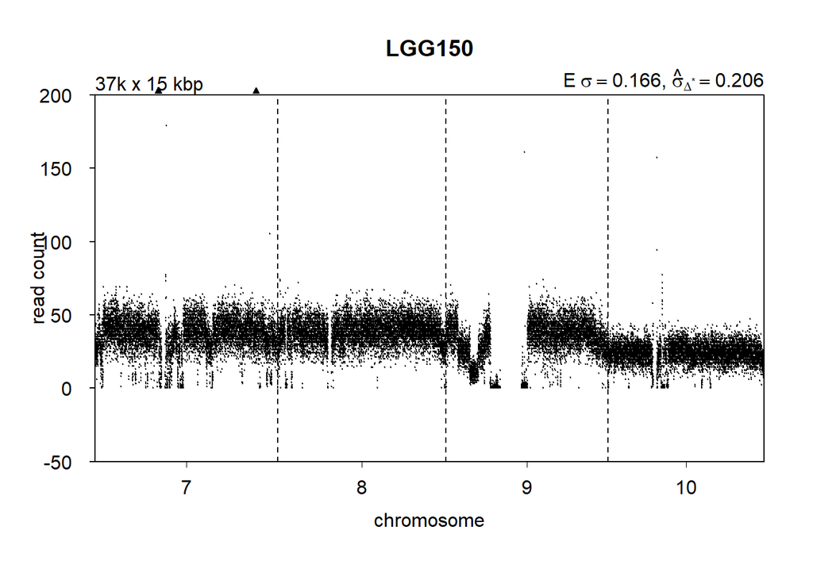

```r
plot(readCounts, logTransform=FALSE, ylim=c(-50, 200))
```

### **Median Read Count Plot**

```r
readCountsFiltered <- applyFilters(readCounts, residual=TRUE, blacklist=TRUE)
```

```
## 38,819   total bins
## 38,819   of which in selected chromosomes
## 36,722   of which with reference sequence
## 33,347   final bins
```

```
## Plotting sample LGG150 median read counts
```

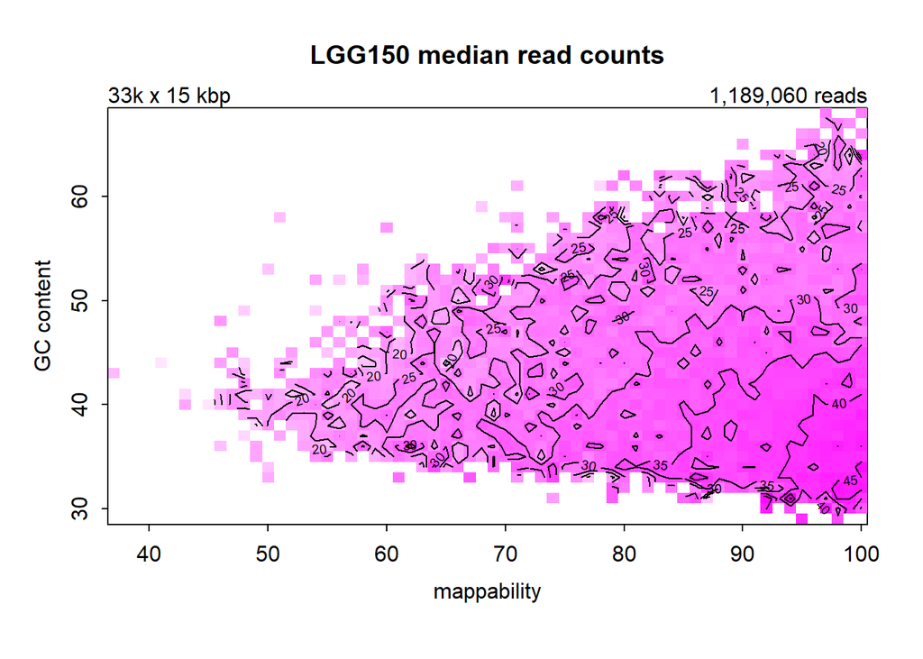

```r
isobarPlot(readCountsFiltered)
```

### **Read Count Noise Plot**

```
## Calculating correction for GC content and mappability
```

```
##     Calculating fit for sample LGG150 (1 of 1) ...
```

```
## Done.
```

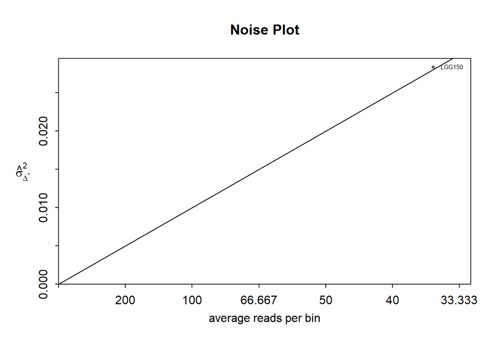

```r
noisePlot(readCountsFiltered)
```

### **Copy Number Filtering**

```r
copyNumbers <- correctBins(readCountsFiltered)
```

```
## Calculating correction for GC content and mappability
```

```
##     Calculating fit for sample LGG150 (1 of 1) ...
```

```
## Done.
```

```r
copyNumbers
```

```
## QDNAseqCopyNumbers (storageMode: lockedEnvironment)
## assayData: 38819 features, 1 samples
##   element names: copynumber
## protocolData: none
## phenoData
##   sampleNames: LGG150
##   varLabels: name reads ... loess.family (6 total)
##   varMetadata: labelDescription
## featureData
##   featureNames: 7:1-15000 7:15001-30000 ... 10:135525001-135534747
##     (38819 total)
##   fvarLabels: chromosome start ... use (9 total)
##   fvarMetadata: labelDescription
## experimentData: use 'experimentData(object)'
## Annotation:
```

```r
copyNumbersNormalized <- normalizeBins(copyNumbers)
```

```
## Applying median normalization ...
```

```r
copyNumbersSmooth <- smoothOutlierBins(copyNumbersNormalized)
```

```
## Smoothing outliers ...
```

### **Filtered Read Count Plot**

```
## Plotting sample LGG150 (1 of 1) ...
```

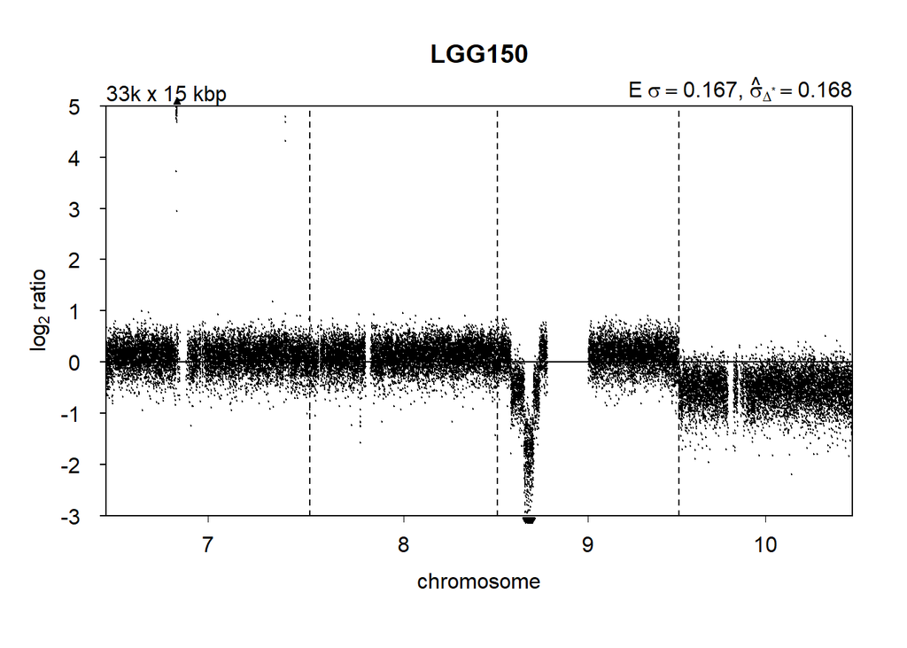

```r
plot(copyNumbersSmooth)
```

### **Exporting Filtered Read Counts**

```r
exportBins(copyNumbersSmooth, file="LGG150.txt")
```

```
## [1] "LGG150.txt"
```

```r
exportBins(copyNumbersSmooth, file="LGG150.igv", format="igv")
```

```
## [1] "LGG150.igv"
```

```r
exportBins(copyNumbersSmooth, file="LGG150.bed", format="bed")
```

```
## [1] "LGG150.bed"
```

## **2.3: Downstream Analysis**

### **Read Count Segmenting**

```r
copyNumbersSegmented <- segmentBins(copyNumbersSmooth, transformFun="sqrt")
```

```
## Performing segmentation:
```

```
##     Segmenting: LGG150 (1 of 1) ...
```

```r
copyNumbersSegmented <- normalizeSegmentedBins(copyNumbersSegmented)
```

### **Segmented Read Count Plot**

```
## Plotting sample LGG150 (1 of 1) ...
```

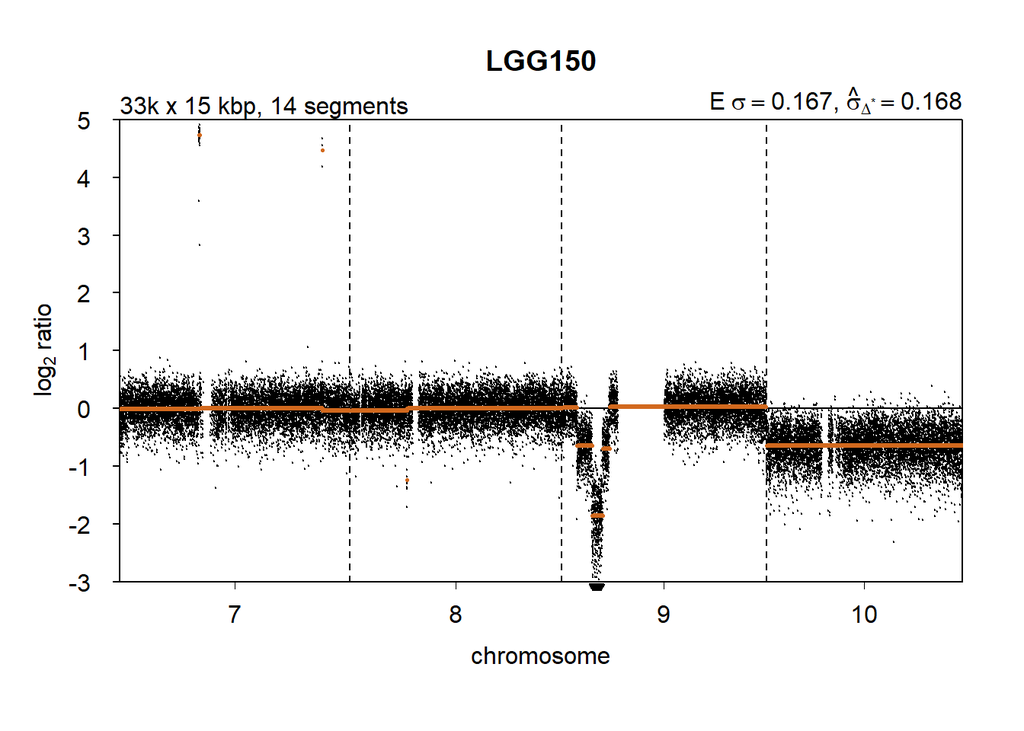

```r
plot(copyNumbersSegmented)
```

### **Called Read Count Plot**

```r
copyNumbersCalled <- callBins(copyNumbersSegmented)
```

```
## [1] "Total number of segments present in the data: 14"
## [1] "Number of segments used for fitting the model: 11"
```

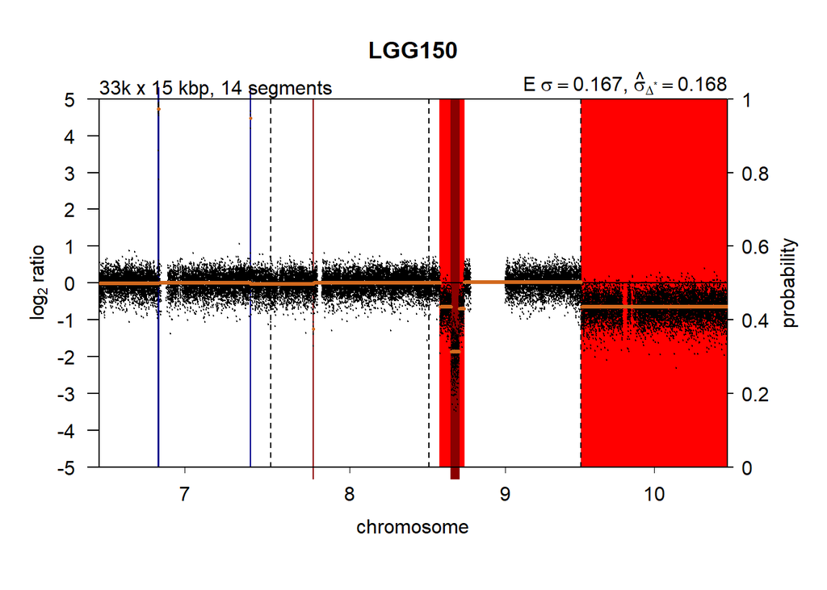

```r
plot(copyNumbersCalled)
```

```r
exportBins(copyNumbersCalled, "copyNumbersCalled.vcf")
```

```
## [1] "copyNumbersCalled.vcf"
```

```r
exportBins(copyNumbersCalled, "copyNumbersCalled.seg")
```

```
## [1] "copyNumbersCalled.seg"
```

### **CGHcall Conversion**

```r
cgh <- makeCgh(copyNumbersCalled)

cgh
```

```
## cghCall (storageMode: lockedEnvironment)
## assayData: 33347 features, 1 samples
##   element names: calls, copynumber, probamp, probdloss, probgain, probloss, probnorm, segmented
## protocolData: none
## phenoData
##   sampleNames: LGG150
##   varLabels: name reads ... loess.family (6 total)
##   varMetadata: labelDescription
## featureData
##   featureNames: 7:45001-60000 7:60001-75000 ... 10:135420001-135435000
##     (33347 total)
##   fvarLabels: Chromosome Start ... use (9 total)
##   fvarMetadata: labelDescription
## experimentData: use 'experimentData(object)'
## Annotation:
```

## **2.4 Parallel Comparison**

### **Parallel Computation**

**QDNAseq** can allow for parallel computing using the **future** package. In order to do this and appropriate plan must be selected. **QDNAseq** currently includes estimateCorrection(), segmentBins(), createBins() and calculateBlacklist() for parallel processing. It also includes binReadcounts() but this only parallelises by chromosome when chunkSize is used. The default argument method=“CGHcall” can be used for parallel computation using the function callBins() or CGHcall(). However the number of processes to use needs to be specified with the argument ncpus.

### **Non-Parallel Processing**

The Default is to use single-core processing via “sequential” futres. This is set by:

```r
future::plan("sequential")
```

### **Parallel Processing on the Current Machine and Adhoc Machine**

Connecting to an Adhoc machine using multiple R sessions the following code or similar should be used:

```
cl <- future::makeClusterPSOCK(...)
future::plan("cluster", cluster=cl)
```

## **3: Sex Chromosome Processing**

**QDNAseq** automatically ignores sex chromosomes by default. in order for them to be included in the analysis, the function applyFilters() should be run with the argument chromosomes=NA (includes both X and Y) or chromsomes=“Y”/chromsomes=“X” to include X or Y respectively.  
This would also affect the calculation of LOESS and should be counteracted by using the estimateCorrection() function. The process should be: Filter Sex Chromosomes, run estimateCorrection() and reverse the sex chromosome filtering.

### **Sex Chromosome QDNAseq**

```
readCounts <- binReadCounts(getBinAnnotations(15))
readCounts <- applyFilters(readCounts)
readCounts <- estimateCorrection(readCounts)
readCounts <- applyFilters(readCounts, chromosomes=NA)
copyNumbers <- correctBins(readCounts)
```